# **Loan Default Prediction**

### **Building a Random Forest Classifier**

**Random Forest is a bagging algorithm where the base models are Decision Trees.** Samples are taken from the training data and on each sample a decision tree makes a prediction.

**The results from all the decision trees are combined together and the final prediction is made using voting or averaging.**

```python
from sklearn.ensemble import RandomForestClassifier

# Define the Random Forest Classifier
random_forest_classifier = RandomForestClassifier(random_state=2)

# You can also specify hyperparameters if needed
# For example:
# random_forest_classifier = RandomForestClassifier(n_estimators=100, max_depth=10, random_state=42)

# Fit the classifier to the data
random_forest_classifier.fit(X_train, y_train)
```

```
RandomForestClassifier(random_state=2)
```

#### Checking the performance on the train dataset

```python
# Predict on the training data
y_train_pred_rf = random_forest_classifier.predict(X_train)

# Evaluate the performance
metrics_score(y_train, y_train_pred_rf)
```

```
              precision    recall  f1-score   support

           0       1.00      1.00      1.00      3844
           1       1.00      1.00      1.00       924

    accuracy                           1.00      4768
   macro avg       1.00      1.00      1.00      4768
weighted avg       1.00      1.00      1.00      4768
```

**Observations:**

#### Checking the performance on the test dataset

```
              precision    recall  f1-score   support

           0       0.90      0.99      0.94       927
           1       0.97      0.61      0.75       265

    accuracy                           0.91      1192
   macro avg       0.93      0.80      0.85      1192
weighted avg       0.91      0.91      0.90      1192
```

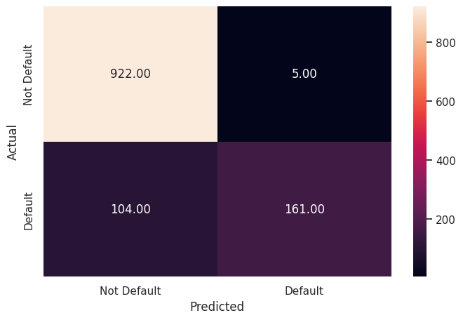

```python
# Predict on the test data
y_test_pred_rf = random_forest_classifier.predict(X_test)

# Evaluate the performance
metrics_score(y_test, y_test_pred_rf)
```

**Observations:**

- The Random Forest is giving a 94% f1 score for category 0 and 74% f1 score for category 1 on the test dataset.

### **Build a Random Forest model with Class Weights**

```python
# Import the Random Forest Classifier
from sklearn.ensemble import RandomForestClassifier

# Define the Random Forest model with class weights
random_forest_classifier = RandomForestClassifier(random_state=2, class_weight={0: 0.2, 1: 0.8})

# Fit the Random Forest model on the training data
random_forest_classifier.fit(X_train, y_train)
```

```
RandomForestClassifier(class_weight={0: 0.2, 1: 0.8}, random_state=2)
```

#### Checking the performance on the train dataset

```python
# Predict on the training data
y_train_pred_rf = random_forest_classifier.predict(X_train)

# Evaluate the performance using the metrics_score function
metrics_score(y_train, y_train_pred_rf)
```

```
              precision    recall  f1-score   support

           0       1.00      1.00      1.00      3844
           1       1.00      1.00      1.00       924

    accuracy                           1.00      4768
   macro avg       1.00      1.00      1.00      4768
weighted avg       1.00      1.00      1.00      4768
```

**Observations:**

#### Checking the performance on the test dataset

```
              precision    recall  f1-score   support

           0       0.89      0.99      0.94       927
           1       0.95      0.55      0.70       265

    accuracy                           0.89      1192
   macro avg       0.92      0.77      0.82      1192
weighted avg       0.90      0.89      0.88      1192
```

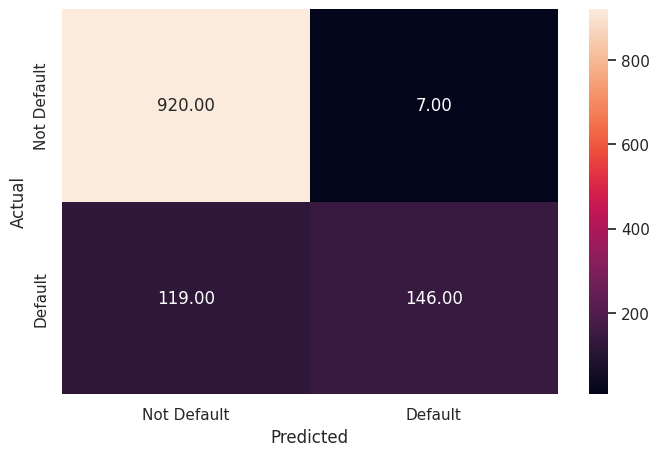

```python
# Predict on the test data
y_test_pred_rf = random_forest_classifier.predict(X_test)

# Evaluate the performance using the metrics_score function
metrics_score(y_test, y_test_pred_rf)
```

**Observations:**

- The Random Forest is giving a 94% f1 score for category 0 and 70% f1 score for category 1 on the test dataset.

### **Random Forest Classifier Hyperparameter Tuning**

```python
# Choose the type of classifier.
#classifier = RandomForestClassifier(random_state=2)

# Grid of parameters to choose from
#param_grid = {
#    'n_estimators': [50, 100, 200],  # Example values for RandomForestClassifier
#    'max_depth': [None, 10, 20, 30],
#    'min_samples_split': [2, 5, 10],
#    'min_samples_leaf': [1, 2, 4],
#    'class_weight': [{0: 0.2, 1: 0.8}, {0: 0.3, 1: 0.7}]  # Adjust the values as needed
#}

# Type of scoring used to compare parameter combinations
#scorer = 'f1'  # You can use other metrics like 'f1', 'precision', 'recall', etc.

# Run the grid search
#from sklearn.model_selection import GridSearchCV
#grid_search = GridSearchCV(classifier, param_grid, scoring=scorer, cv=5)
#grid_search.fit(X_train, y_train)

# Fit the GridSearch on the train dataset
#best_classifier = grid_search.best_estimator_

# Set the classifier to the best combination of parameters
#classifier = grid_search.best_estimator_

# Fit the best algorithm to the data.
#classifier.fit(X_train, y_train)
```

```python
#RandomForestClassifier(class_weight={0: 0.2, 1: 0.8}, max_depth=30,
                       #min_samples_split=10, random_state=147)
```

```python
# Define the classifier with specified parameters
classifier = RandomForestClassifier(class_weight={0: 0.22, 1: 0.78}, max_depth=30,
                       min_samples_split=10, random_state=147)
```

```python
# Fit the model on the training data
classifier.fit(X_train, y_train)
```

```
RandomForestClassifier(class_weight={0: 0.22, 1: 0.78}, max_depth=30,
                       min_samples_split=10, random_state=147)
```

#### Checking the performance on the train dataset

```
              precision    recall  f1-score   support

           0       1.00      1.00      1.00      3844
           1       0.99      0.99      0.99       924

    accuracy                           1.00      4768
   macro avg       1.00      1.00      1.00      4768
weighted avg       1.00      1.00      1.00      4768
```

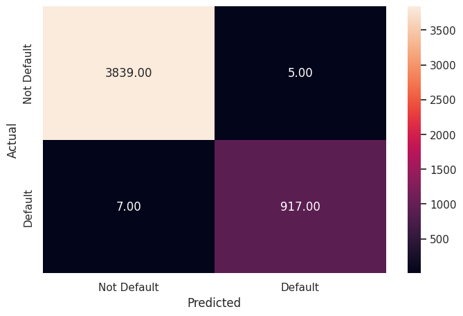

```python
# Checking performance on the training data
y_train_pred = classifier.predict(X_train)

# Use the metrics_score function
metrics_score(y_train, y_train_pred)
```

**Observations:**

#### Checking the performance on the test dataset

```
              precision    recall  f1-score   support

           0       0.91      0.98      0.94       927
           1       0.90      0.67      0.77       265

    accuracy                           0.91      1192
   macro avg       0.91      0.83      0.86      1192
weighted avg       0.91      0.91      0.91      1192
```

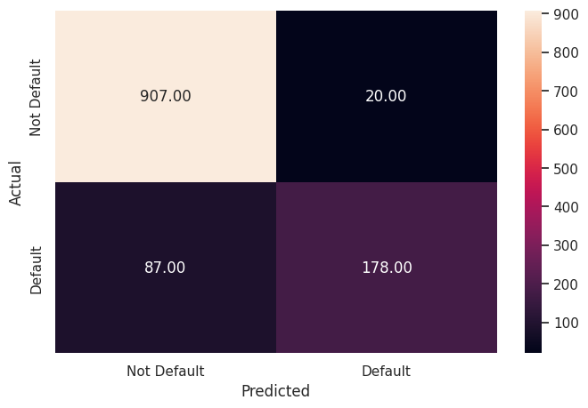

```python
# Checking performance on the test data
y_test_pred = classifier.predict(X_test)

# Use the metrics_score function
metrics_score(y_test, y_test_pred)
```

**Observations:**

- The Tuned Random Forest is giving a 94% f1 score for category 0 and 77% f1 score for category 1 on the test dataset.